# Math 300 NTI Lesson 33

More on Hypothesis Tests

Professor Bradley Warner

July, 2022

## Objectives

1. Standardize a variable.
2. Find percentile and probabilities for the t distribution; this includes determining the correct degrees of freedom.
3. Use the `infer` package to conduct a theory-based hypothesis test.
4. Know and verify the assumptions of the two-sample t-test.

## Reading

[Chapter 9.6](https://moderndive.com/9-hypothesis-testing.html#nhst-conclusion)

## Lesson

*Remember that you will be running this more like a lab than a lecture. You want them using `R` and answering questions. Have them open the notes rmd and work through it together.*

There are no learning checks for this section.

- The material in this section is the traditional small sample normal-based inference. It is good to present this so they are familiar with the material. Point out the differences and the assumptions needed.

*These traditional theory-based methods have been used for decades mostly because researchers didn’t have access to computers that could run thousands of calculations quickly and efficiently. Now that computing power is much cheaper and more accessible, simulation-based methods are much more feasible. However, researchers in many fields continue to use theory-based methods. Hence, we make it a point to include an example here.*

- Often, when using traditional methods, we have to *standardize* a variable to get a mathematical solution for the sampling distribution of that variable (i.e., difference in means, the t distribution). Standardization can be helpful in other ways as well, such as comparisons between two quantities on different scales (ACT vs SAT scores). Note that we don’t have to standardize when using computational methods.
- Spend a little time on the formula for the t statistic when considering the difference of two means.
- Spend time on the problem with p-values. Read the papers and point out key ideas from the reading. Have students read some of the referenced links.

### Libraries

```r
library(tidyverse)
library(infer)
library(moderndive)
library(nycflights13)
library(ggplot2movies)
```

## Problem

Let’s use the 2013 airline data to test the hypothesis that United Airlines flights arrive at their destination with a different delay than Delta flights on average. We will take a sample even though we have the computational power to look at all the flights.

### Data

Let’s get a sample.

```r
set.seed(90)
flight_sample <- flights %>%
  select(arr_delay, carrier,origin) %>%
  filter(carrier%in%c("DL","UA")) %>%
  group_by(carrier) %>%
  slice_sample(n=50) %>%
  ungroup()
```

### EDA

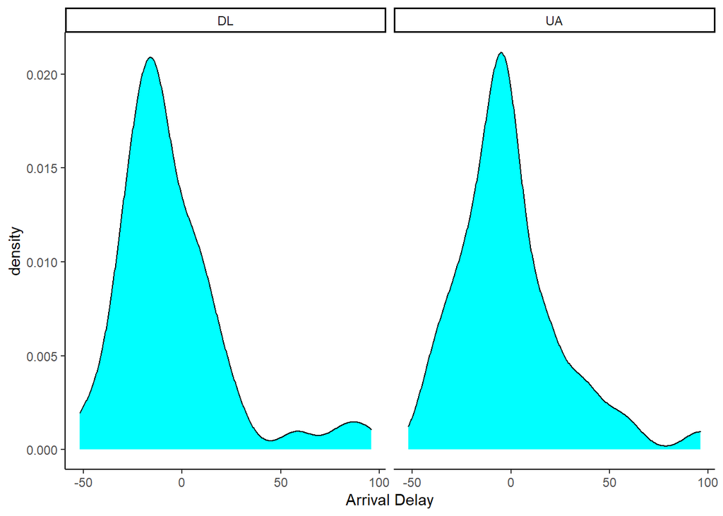

```r
ggplot(data = flight_sample, aes(x = arr_delay)) +
  geom_density(fill="cyan") +
  facet_wrap(~carrier)+
  labs(x = "Arrival Delay") +
  theme_classic()
```

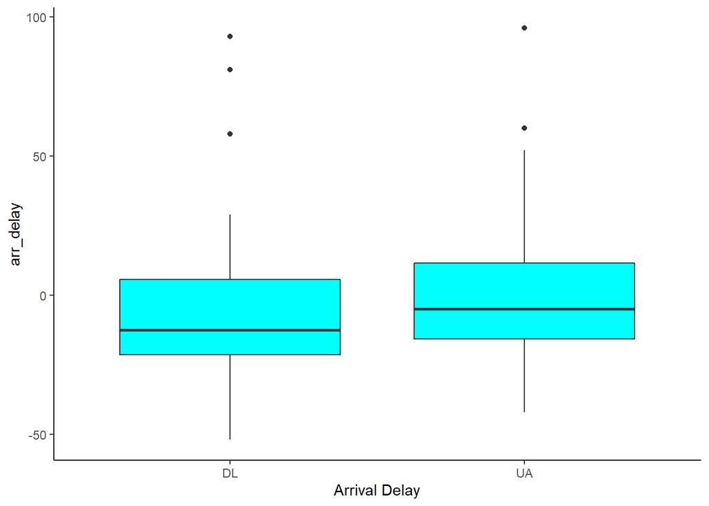

```r
ggplot(data = flight_sample, aes(y = arr_delay, x= carrier)) +
  geom_boxplot(fill="cyan") +
  labs(x = "Arrival Delay") +
  theme_classic()
```

```r
flight_sample %>%
  group_by(carrier) %>%
  summarize(n = n(), mean_delay = mean(arr_delay), std_dev = sd(arr_delay))
```

```
## # A tibble: 2 x 4
##   carrier     n mean_delay std_dev
##   <chr>   <int>      <dbl>   <dbl>
## 1 DL         50      -5.84    27.4
## 2 UA         50      -0.68    26.5
```

The data is skewed with outliers, especially for Delta. This will cause problems for the theory-based method which assumes normality. We will run the test and also the simulation-based test.

### Hypothesis Test Theory-based

```r
# Get the null distribution
null_dist <- flight_sample %>%
  specify(formula = arr_delay ~ carrier) %>%
  assume("t")
```

```r
# Find observed difference
obs_flights_mean_diff <- flight_sample %>%
  specify(formula = arr_delay ~ carrier) %>%
  hypothesize(null = "independence") %>%
#  generate(reps = 1000, type = "permute") %>%
  calculate(stat = "t", order = c("DL", "UA"))
```

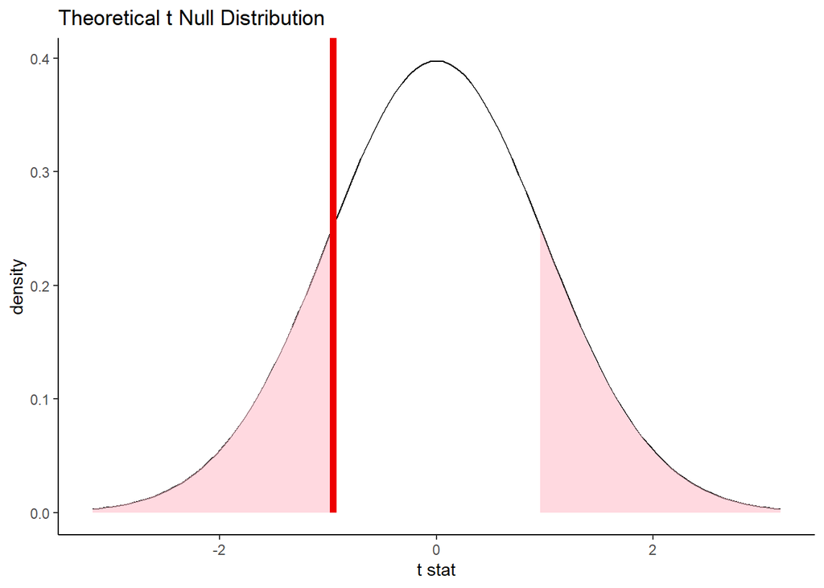

```r
visualize(null_dist) +
  theme_classic() +
  shade_p_value(obs_stat = obs_flights_mean_diff, direction = "both")
```

```r
#Get p-value
null_dist %>%
  get_p_value(obs_stat = obs_flights_mean_diff, direction = "both")
```

```
## # A tibble: 1 x 1
##   p_value
##     <dbl>
## 1   0.341
```

### Hypothesis Test Permutation

This method does not assume normality.

```r
# Get the null distribution
null_dist_permute <- flight_sample %>%
  specify(formula = arr_delay ~ carrier) %>%
  hypothesize(null = "independence") %>%
  generate(reps = 1000, type = "permute") %>%
  calculate(stat = "diff in means", order = c("DL", "UA"))
```

```r
# Find observed difference
obs_flights_mean_diff_permute <- flight_sample %>%
  specify(formula = arr_delay ~ carrier) %>%
  calculate(stat = "diff in means", order = c("DL", "UA"))
```

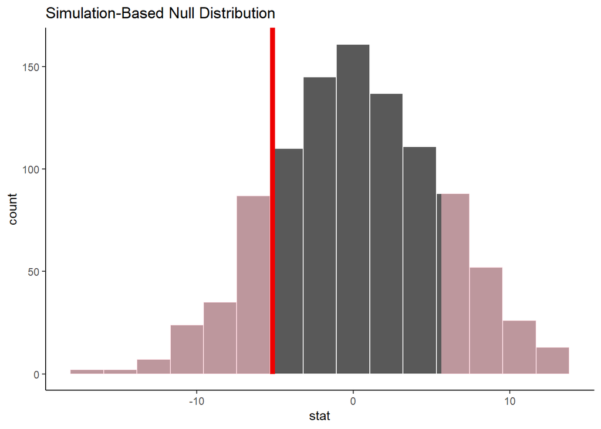

```r
visualize(null_dist_permute) +
  theme_classic() +
  shade_p_value(obs_stat = obs_flights_mean_diff_permute, direction = "both")
```

```r
#Get p-value
null_dist_permute %>%
  get_p_value(obs_stat = obs_flights_mean_diff_permute, direction = "both")
```

```
## # A tibble: 1 x 1
##   p_value
##     <dbl>
## 1   0.324
```

The p-values are close.

### Confidence Interval

```r
null_dist_permute %>%
  get_ci(level=0.95,type="percentile")
```

```
## # A tibble: 1 x 2
##   lower_ci upper_ci
##      <dbl>    <dbl>
## 1    -10.0     10.5
```

We could use medians instead of means in the permutation test. It will not be as sensitive to the outliers.

### Confidence Interval for Medians

```r
# Get the null distribution
null_dist_permute_median <- flight_sample %>%
  specify(formula = arr_delay ~ carrier) %>%
  hypothesize(null = "independence") %>%
  generate(reps = 1000, type = "permute") %>%
  calculate(stat = "diff in medians", order = c("DL", "UA"))
```

```r
null_dist_permute_median %>%
  get_ci(level=0.95,type="percentile")
```

```
## # A tibble: 1 x 2
##   lower_ci upper_ci
##      <dbl>    <dbl>
## 1    -8.51      9.5
```

## Documenting software

- File creation date: 2022-07-11
- R version 4.1.1 (2021-08-10)
- `tidyverse` package version: 1.3.1
- `moderndive` package version: 0.5.4
- `infer` package version: 1.0.2
- `nycflights13` package version: 1.0.2
- `ggplot2movies` package version: 0.0.1